# Predicting Credit Card Fraud

Andrej Arpáš

2022-06-19

```r
rm(list = ls()) # clean glob. computing environment
```

```r
# gc() # garbage collect
```

We fetch the dataset from [here](https://github.com/CapitalOneRecruiting/DS). This notebook uses a **20,000-row** extract (`data/transactions_sample.jsonl`) so the analysis is reproducible from the repo; drop the full `transactions.txt` into `data/` to rerun on the complete Capital One dump.

```python
import pandas as pd
from pathlib import Path

data_path = Path("data/transactions_sample.jsonl")
if not data_path.exists():
    data_path = Path("data/transactions.txt")
df = pd.read_json(data_path, lines=True)
```

```python
df.head()
```

```
##    accountNumber  customerId  ...  expirationDateKeyInMatch  isFraud
## 0      737265056   737265056  ...                     False    False
## 1      737265056   737265056  ...                     False    False
## 2      737265056   737265056  ...                     False    False
## 3      737265056   737265056  ...                     False    False
## 4      830329091   830329091  ...                     False    False
##
## [5 rows x 29 columns]
```

```r
library(reticulate)

d <- reticulate::py$df # convert to r obj. for dplyr manipulation (faster), and 'gg' plotting (prettier)
```

Let’s switch to R for piping.

# Q1: Load

“Programmatically download and load the transactions data. Describe the structure. Provide some additional basic summary statistics for each field. Be sure to include a count of null, minimum, maximum, and unique values where appropriate.”

```r
d[1, 20] # `echoBuffer`, i.e. 20th col. in 1st row: ""
```

```
## [1] ""
```

We have some rows and cols with `''` in lieu of NA. Let’s fix that. Specifically, we can do away with `echoBuffer`, `merchantCity`, `merchantState`, `merchantZip`, `posOnPremises`, and `recurringAuthInd`. (Their missingness is 100%.)

```r
library(naniar)
library(dplyr)
```

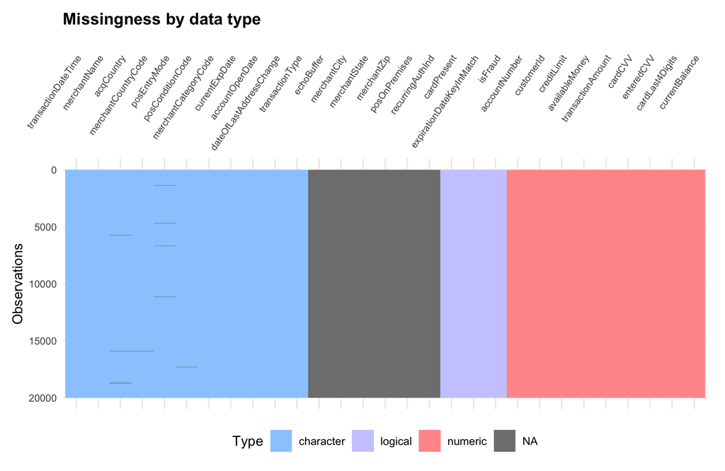

```r
library(ggplot2)
d_miss <- d %>%
  mutate(across(.fns = ~ replace(., . == "", NA)))
# vis_dat on 20k rows is dense; fix title/margins so labels do not collide.
visdat::vis_dat(d_miss, warn_large_data = FALSE) +
  scale_fill_manual(
    values = c(
      numeric = "#FF9999",
      logical = "#CCCCFF",
      missing = "gray53",
      character = "#99CCFF"
    )
  ) +
  labs(title = "Missingness by data type", fill = NULL) +
  theme_minimal(base_size = 11) +
  theme(
    plot.title = element_text(size = 13, face = "bold", margin = margin(b = 8)),
    axis.text.x = element_text(angle = 55, hjust = 1, vjust = 1, size = 7.5),
    axis.text.y = element_text(size = 8),
    legend.position = "bottom",
    plot.margin = margin(10, 14, 10, 10),
    panel.grid.minor = element_blank()
  )
```

Let us display that missingness also numerically.

```r
d %>%
  mutate(across(.fns = ~replace(., . == '', NA))) %>%
  is.na() %>%
  colSums() # missingness per col.
```

```
##            accountNumber               customerId              creditLimit
##                        0                        0                        0
##           availableMoney      transactionDateTime        transactionAmount
##                        0                        0                        0
##             merchantName               acqCountry      merchantCountryCode
##                        0                      115                       14
##             posEntryMode         posConditionCode     merchantCategoryCode
##                      125                       14                        0
##           currentExpDate          accountOpenDate  dateOfLastAddressChange
##                        0                        0                        0
##                  cardCVV               enteredCVV          cardLast4Digits
##                        0                        0                        0
##          transactionType               echoBuffer           currentBalance
##                       17                    20000                        0
##             merchantCity            merchantState              merchantZip
##                    20000                    20000                    20000
##              cardPresent            posOnPremises         recurringAuthInd
##                        0                    20000                    20000
## expirationDateKeyInMatch                  isFraud
##                        0                        0
```

And let’s calculate some basic descriptive statistics for our numeric variables.

```r
# summary stats for numeric cols
purrr::map_dfr(lst(min, median, mean, max, sd),
               ~ summarize(d[, !(names(d) %in% c('accountNumber', 'customerId', 'cardCVV', 'enteredCVV', 'cardLast4Digits'))], across(where(is.numeric), .x, na.rm = TRUE)), # drop non-pertinent cols, e.g. `accountNumber`
               .id = 'summary_stats')
```

```
##   summary_stats creditLimit availableMoney transactionAmount currentBalance
## 1           min     250.000       -745.710            0.0000          0.000
## 2        median    5000.000       2318.230           85.6400       1117.585
## 3          mean    8835.787       5452.621          135.8416       3383.167
## 4           max   50000.000      50000.000         1245.0500      47489.500
## 5            sd   11369.553       7926.788          147.2959       6814.217
```

Do note that there are some suspect values, e.g. `enteredCVV` being nill (`0`), or `0` for `cardLast4Digits`.

```r
# drop cols with 100% missingness, and drop na
e <- d %>%
  mutate(across(.fns = ~replace(., . == '', NA))) %>%
  select(-one_of(c('echoBuffer', 'merchantCity', 'merchantState',
                   'merchantZip', 'posOnPremises', 'recurringAuthInd'))) %>%
  tidyr::drop_na()
```

$`0` transactions seem to be “verification” transactions allegedly used by merchants to validate card / account details.

# Q2: Plot

“Plot a histogram of the processed amounts of each transaction, the `transactionAmount` column. Report any structure you find and any hypotheses you have about that structure.”

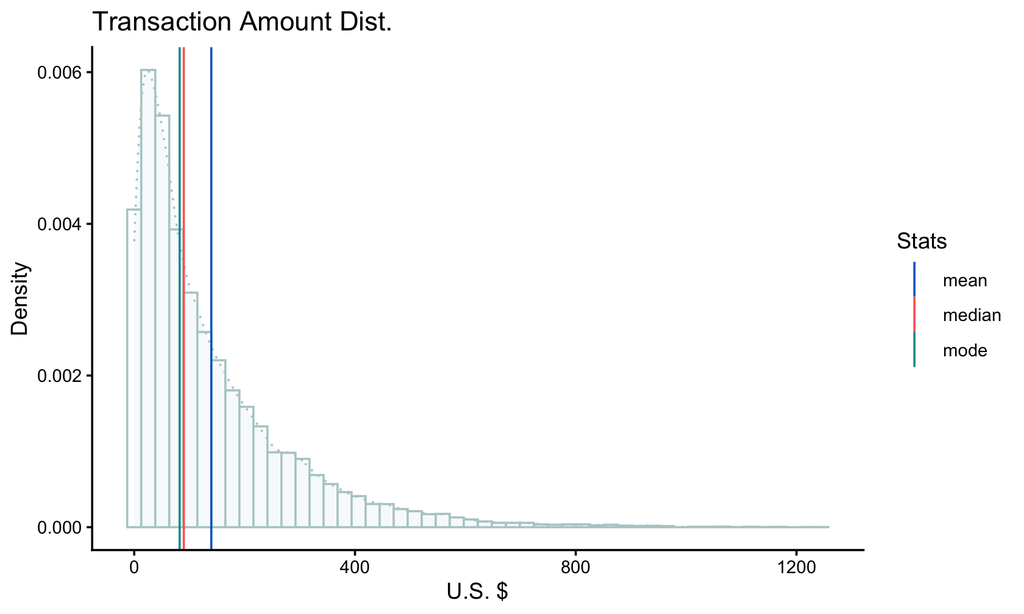

```r
library(ggplot2)

myMode <- function(x) {
  uniqX <- unique(x)
  tabRes <- tabulate(match(x, uniqX))
  uniqX[tabRes == max(tabRes)]
}

amt <- e$transactionAmount[e$transactionAmount != 0]
n_zero <- sum(e$transactionAmount == 0)
vlines <- data.frame(
  value = c(mean(amt), max(myMode(amt)), median(amt)),
  stats = c("mean", "mode", "median")
)

e %>%
  filter(transactionAmount != 0) %>%
  ggplot(aes(x = transactionAmount)) +
  geom_histogram(
    aes(y = after_stat(density)),
    fill = "white",
    color = "lightcyan3",
    bins = 50,
    show.legend = FALSE
  ) +
  geom_density(alpha = 0.1, fill = "lightcyan3", color = "lightcyan3", linetype = 3) +
  theme_classic() +
  geom_vline(
    data = vlines,
    aes(xintercept = value, color = stats),
    linewidth = 0.5,
    show.legend = TRUE
  ) +
  labs(
    title = "Transaction Amount Dist.",
    x = "U.S. $",
    y = "Density"
  ) +
  scale_colour_manual(
    name = "Stats",
    values = c(mean = "#0066CC", median = "#FF6666", mode = "#009999"),
    labels = c("mean", "median", "mode")
  )
```

```r
tibble(
  n_zero_dollar = n_zero,
  mode_amt = max(myMode(amt)),
  median_amt = median(amt),
  mean_amt = mean(amt)
)
```

```
## # A tibble: 1 × 4
##   n_zero_dollar mode_amt median_amt mean_amt
##           <int>    <dbl>      <dbl>    <dbl>
## 1           515     82.3       89.9     140.
```

After dropping 515 zero-dollar transactions in this extract (verification-style charges in the original write-up), we have mode < median < mean — a right-skewed distribution. What stands out is that most transactions happen in the lower dollar-brackets (dropping off rather dramatically after ~$500), and that by far the greatest chunk of the transactions happen under the median.

Another thing to think about is, it’d seem as though the transactions’ dynamics are driven by what we might refer to as “frivolous” transactions, i.e. small-amount transactions. Since these are credit cards, that would seem to be a suboptimal behavior for the card-holder who, instead, should aim to use their credit cards for big-ticket items. This would appear to be a feature to exploit, though perhaps the fact we see some semblance of this behavior is an indication that it has already been exploited.

# Q3: Data Wrangling - Duplicate Transactions

“Duplicated transactions: (i) **reversed transaction** (purchase followed by a reversal), and (ii) **multi-swipe transactions** (vendor accidentally charges a customer’s card multiple times within a short time span).”

```r
# reversed transactions (discounting verif. / $`0` transactions)
e %>%
  filter(transactionAmount != 0) %>%
  mutate(dateTime = lubridate::ymd_hms(e[e$transactionAmount != 0, 5])) %>%
  filter(transactionType == 'REVERSAL') %>%
  select(accountNumber, transactionAmount, currentBalance, dateTime, merchantName, transactionType) %>%
  group_by(accountNumber, transactionAmount) %>% # 19,488 records
  as.data.frame() %>%
  select(transactionAmount) %>%
  sum() # $2,787,895
```

```
## [1] 68431.34
```

```r
# multi-swipe transaction (discounting verif. / $`0` transactions)
multiSwipeTransaction <- e %>% # 14,205 x 10
  filter(transactionAmount != 0) %>%
  mutate(dateTime = lubridate::ymd_hms(e[e$transactionAmount != 0, 5])) %>%
  filter(transactionType != 'REVERSAL') %>% # filter out reversal transactions
  select(accountNumber, transactionAmount, currentBalance, dateTime, merchantName) %>%
  group_by(accountNumber, transactionAmount) %>% # transactionAmount, transactionDateTime
  filter(n() > 1) %>%
  mutate(date = as.Date(dateTime),
         hour = lubridate::hour(dateTime),
         minute = lubridate::minute(dateTime),
         second = lubridate::second(dateTime)) %>%
  mutate(hourMinuteSecond = paste(hour, minute, second, sep = ":")) %>%
  group_by(accountNumber, transactionAmount, date) %>%
  filter(n() > 1)
```

```r
firstTransactions <- multiSwipeTransaction %>%
  group_by(accountNumber, transactionAmount) %>%
  summarise() # %>% # 6,763 x 2
  # as.data.frame() %>%
  # select(transactionAmount) %>%
  # sum() # $996,154.8

dim(multiSwipeTransaction)[1] - dim(firstTransactions)[1] # 7442
```

```
## [1] 217
```

```r
sum(multiSwipeTransaction$transactionAmount) - sum(firstTransactions$transactionAmount) # $1,097,507
```

```
## [1] 36587.01
```

# Q4: Model

“Build a predictive model to determine whether a given transaction will be fraudulent (`isFraud`) or not.”

```r
# a bit more of that feature engineering stuff
e$merchantName %>%
  unique() %>%
  length() # 2489 vendors
```

```
## [1] 2020
```

```r
fraudInTime <- e %>%
  filter(transactionAmount != 0) %>%
  mutate(dateTime = lubridate::ymd_hms(e[e$transactionAmount != 0, 5])) %>%
  select(-one_of(c('transactionDateTime'))) %>%
  mutate(date = as.Date(dateTime)) %>%
  mutate(fraud = isFraud == TRUE,
         noFraud = isFraud == FALSE) %>%
  group_by(date) %>%
  summarise_at(vars(fraud, noFraud),
               list('n' = ~sum(. != 0),
                    'prop' = ~(sum(. != 0) / n()))) %>%
  rename(noFraud = noFraud_n,
       fraud = fraud_n) %>%
  tidyr::pivot_longer(cols = -date) %>%
  mutate(count = ifelse(name == 'fraud' | name == 'noFraud', value, NA),
         isFraud = ifelse(name == 'fraud' | name == 'noFraud', name, NA),
         prop = ifelse(name == 'fraud_prop' | name == 'noFraud_prop', value, NA)) %>%
  select(-one_of(c('value', 'name'))) %>%
  mutate(prop = lead(prop),
         prop = lead(prop)) %>%
  tidyr::drop_na()
```

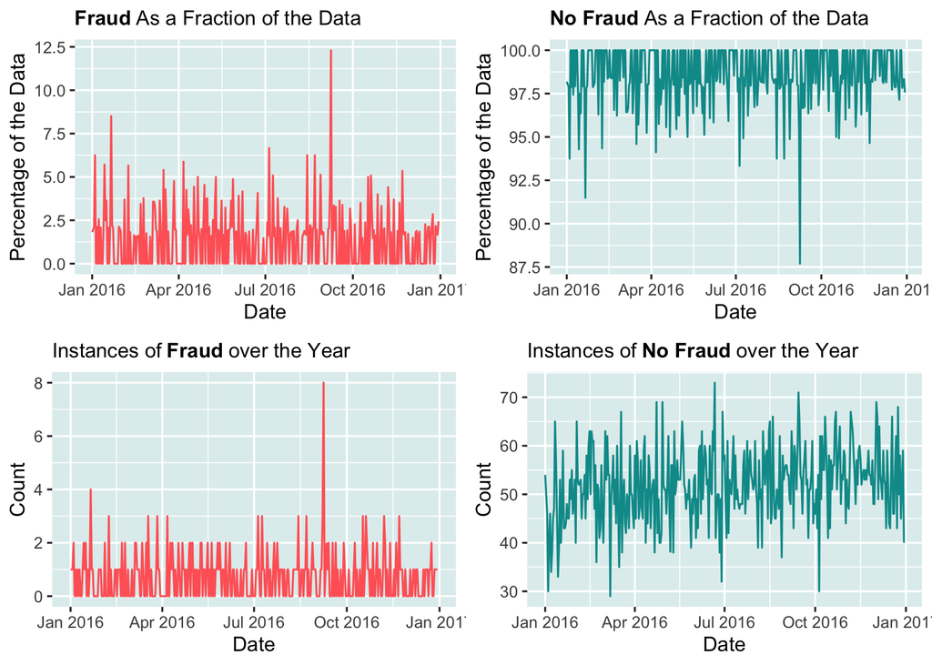

```r
p1 <- fraudInTime %>%
  slice(which(row_number() %% 2 == 1)) %>% # fraud
  # slice(seq(2, n(), by = 2)) # noFraud
  ggplot2::ggplot(aes(x = date, y = prop * 100)) +
  geom_line(color = '#FF6666') +
  # coord_cartesian(ylim = c(0.5, 2.5)) +
  theme(panel.background = element_rect(fill = 'azure2'), panel.grid = element_line(color = 'white'),
        plot.title = element_text(size=11)) +
  labs(title = bquote(bold('Fraud') ~'As a Fraction of the Data'), x = 'Date', y = 'Percentage of the Data')

p2 <- fraudInTime %>%
  # slice(which(row_number() %% 2 == 1)) %>% # fraud
  slice(seq(2, n(), by = 2)) %>% # noFraud
  ggplot2::ggplot(aes(x = date, y = prop * 100)) +
  geom_line(color = '#009999') +
  # coord_cartesian(ylim = c(97, 99.5)) +
  theme(panel.background = element_rect(fill = 'azure2'), panel.grid = element_line(color = 'white'),
        plot.title = element_text(size=11)) +
  labs(title = bquote(bold('No Fraud') ~'As a Fraction of the Data'), x = 'Date', y = 'Percentage of the Data')

p3 <- fraudInTime %>%
  slice(which(row_number() %% 2 == 1)) %>% # fraud
  # slice(seq(2, n(), by = 2)) # noFraud
  ggplot2::ggplot(aes(x = date, y = count)) +
  geom_line(color = '#FF6666') +
  theme(panel.background = element_rect(fill = 'azure2'), panel.grid = element_line(color = 'white'),
        plot.title = element_text(size=11)) +
  labs(title = bquote('Instances of' ~ bold('Fraud') ~'over the Year'), x = 'Date', y = 'Count')

p4 <- fraudInTime %>%
  # slice(which(row_number() %% 2 == 1)) %>% # fraud
  slice(seq(2, n(), by = 2)) %>% # noFraud
  ggplot2::ggplot(aes(x = date, y = count)) +
  geom_line(color = '#009999') +
  theme(panel.background = element_rect(fill = 'azure2'), panel.grid = element_line(color = 'white'),
        plot.title = element_text(size=11)) +
  labs(title = bquote('Instances of' ~ bold('No Fraud') ~'over the Year'), x = 'Date', y = 'Count')

gridExtra::grid.arrange(p1, p2, p3, p4)
```

No particular pattern to observe as a time series, except that the count of no fraud increases over the year, which, however, may merely be on account of more transactions happening as time goes on. (We see no dramatic changes when looking at the data as a fraction of the total. We may cautiosly disregard time as a variable for the purposes of our modeling.)

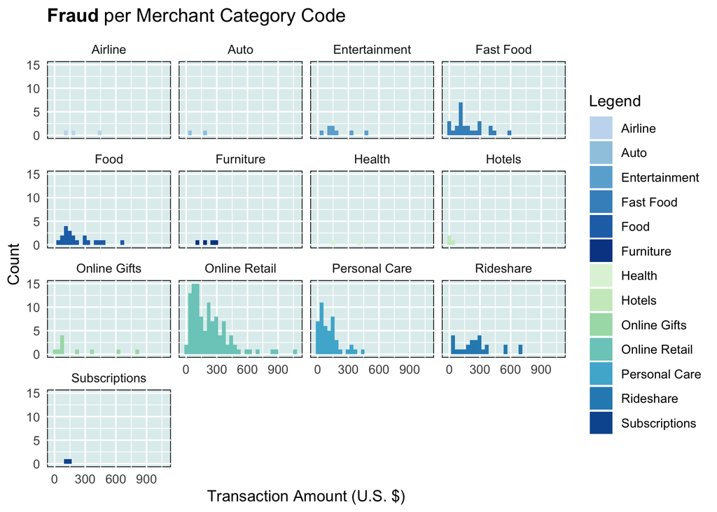

```r
library(RColorBrewer)
myCols = c(brewer.pal(name = 'Blues', n = 8)[3:8], brewer.pal(name = 'GnBu', n = 8)[2:8])

e %>%
  filter(transactionAmount != 0) %>%
  mutate(dateTime = lubridate::ymd_hms(e[e$transactionAmount != 0, 5])) %>%
  select(-one_of(c('transactionDateTime'))) %>%
  mutate(date = as.Date(dateTime)) %>%
  filter(transactionType == "PURCHASE", as.logical(isFraud)) %>%
  ggplot(., aes(x = transactionAmount,
                fill = merchantCategoryCode)) +
    geom_histogram() +
    # facet_wrap(~merchantCategoryCode) +
    facet_wrap(~merchantCategoryCode, # facet_grid()
               labeller = as_labeller(c('rideshare' = 'Rideshare', 'entertainment' = 'Entertainment', 'mobileapps' = 'Mobile Apps', 'fastfood' = 'Fast Food', 'food_delivery' = 'Food Delivery',
                                        'auto' = 'Auto', 'online_retail' = 'Online Retail', 'gym' = 'Gym', 'health' = 'Health', 'personal care' = 'Personal Care',
                                        'food' = 'Food', 'fuel' = 'Fuel', 'online_subscriptions' = 'Online Subscriptions', 'online_gifts' = 'Online Gifts', 'hotels' = 'Hotels',
                                        'airline' = 'Airline', 'furniture' = 'Furniture', 'subscriptions' = 'Subscriptions', 'cable/phone' = 'Cable / Phone'))) +
    theme_minimal() +
    theme(panel.background = element_rect(fill = 'azure2'), panel.grid = element_line(color = 'white')) +
    scale_fill_manual('Legend',
                      labels = c('Airline', 'Auto', 'Entertainment', 'Fast Food', 'Food', 'Furniture', 'Health', 'Hotels', 'Online Gifts',
                                 'Online Retail', 'Personal Care', 'Rideshare', 'Subscriptions'),
                      values = myCols) +
    scale_color_manual(values = myCols) +
    labs(title = bquote(bold('Fraud') ~'per Merchant Category Code'), x = 'Transaction Amount (U.S. $)', y = 'Count')
```

It seems plausible that certain merchant-type transactions are more prone to fraud, such as online retail. Including this info in the model might not be bad idea.

Already did a `corrplot` and there’s not a whole lot in there. Let’s do some manipulations to come up with new variables that might help with the predictiveness. For instance, we shall surmise that frauds may tend to happen at a particular time in a day (perhaps later on), and that there are some merchants in that online retail business (or elsewhere) that are a good indicator of a fraud potentially occurring. Let’s add two new column indicators like that to help with the modeling.

```r
e %>%
  filter(transactionAmount != 0) %>% # filter out verif. transactions
  mutate(dateTime = lubridate::ymd_hms(e[e$transactionAmount != 0, 5])) %>%
  select(-one_of(c('transactionDateTime'))) %>%
  mutate(date = as.Date(dateTime)) %>%
  mutate(
    isFraud = as.integer(as.logical(isFraud)),
    expirationDateKeyInMatch = as.integer(as.logical(expirationDateKeyInMatch)),
    cardPresent = as.integer(as.logical(cardPresent))
  ) %>%
  filter(transactionType == 'PURCHASE') %>%
  mutate(merchantCategoryCode = as.numeric(as.factor(merchantCategoryCode))) %>%
  filter(isFraud == 1) %>%
  group_by(merchantName, isFraud) %>%
  count() %>%
  arrange(desc(n)) %>%
  print(n=22) # top 22 with count >= 100
```

```
## # A tibble: 100 × 3
## # Groups:   merchantName, isFraud [100]
##    merchantName            isFraud     n
##    <chr>                     <int> <int>
##  1 walmart.com                   1    35
##  2 Uber                          1    16
##  3 ebay.com                      1    13
##  4 Lyft                          1    10
##  5 sears.com                     1    10
##  6 gap.com                       1     9
##  7 apple.com                     1     8
##  8 cheapfast.com                 1     8
##  9 discount.com                  1     6
## 10 staples.com                   1     6
## 11 Fresh eCards                  1     5
## 12 West End Beauty #178111       1     5
## 13 West End Beauty #234021       1     5
## 14 West End Beauty #26875        1     5
## 15 target.com                    1     5
## 16 Franks Pub #934222            1     4
## 17 West End Beauty #542603       1     4
## 18 alibaba.com                   1     4
## 19 oldnavy.com                   1     4
## 20 West End Beauty #195148       1     3
## 21 West End Beauty #373881       1     3
## 22 Boston Fries                  1     2
## # ℹ 78 more rows
```

```r
topOffender = c('Lyft', 'ebay.com', 'Fresh Flowers', 'Uber', 'cheapfast.com',
                'walmart.com', 'sears.com', 'oldnavy.com', 'staples.com', 'alibaba.com',
                'amazon.com', 'gap.com', 'target.com', 'apple.com', 'discount.com',
                'American Airlines', 'Fresh eCards', 'Blue Mountain Online Services', 'Next Day Online Services', 'Blue Mountain eCards',
                'Fresh Online Services', 'Mobile eCards')
```

```r
f <- e %>%
  filter(transactionAmount != 0) %>% # filter out verif. transactions
  mutate(dateTime = lubridate::ymd_hms(e[e$transactionAmount != 0, 5])) %>%
  select(-one_of(c('transactionDateTime'))) %>%
  # mutate(date = as.Date(dateTime)) %>%
  mutate(date = as.Date(dateTime),
         hour = lubridate::hour(dateTime),
         minute = lubridate::minute(dateTime),
         second = lubridate::second(dateTime)) %>%
  mutate(
    isFraud = as.integer(as.logical(isFraud)),
    expirationDateKeyInMatch = as.integer(as.logical(expirationDateKeyInMatch)),
    cardPresent = as.integer(as.logical(cardPresent))
  ) %>%
  filter(transactionType == 'PURCHASE') %>%
  mutate(merchantCategoryCode = as.numeric(as.factor(merchantCategoryCode))) %>% # convert to numeric
  mutate(theWeeHoursTransactions = ifelse(hour >= 18 | hour <= 6, 1, 0)) %>% # col. for transactions happening in "the wee hours" 6pm-6am
  mutate(topOffender = ifelse(merchantName %in% topOffender, 1, 0)) %>% # col. indicator if top "offender" merchant (fraud-wise)
  mutate(wrongPin = ifelse(as.character(cardCVV) == as.character(enteredCVV), 0, 1)) %>% # indicator of whether the cvv entered matched the card's
  select(-one_of(c('cardCVV', 'enteredCVV', 'hour', 'minute', 'second'))) %>%
  # group_by(isFraud, wrongPin) %>%
  # count()
  select_if(., is.numeric)
```

Another new variable we may be curious to create, and explore, is checking whether at the time of a transaction, the CVV code entered matched the card’s CVV. The assumption being that a fraudulent transaction may be one where the PIN isn’t matched. Let’s try that, and check.

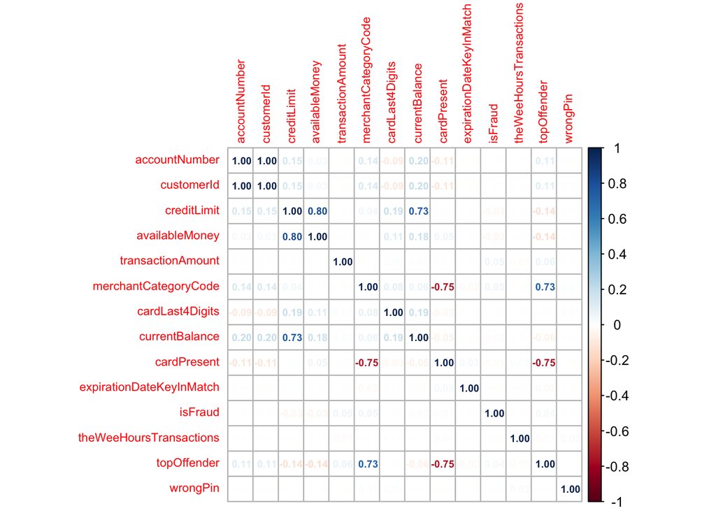

```r
f %>%
  cor() %>%
  round(., 4) %>%
  corrplot::corrplot(., method = 'number', tl.cex = 0.7, number.cex = 0.6)
```

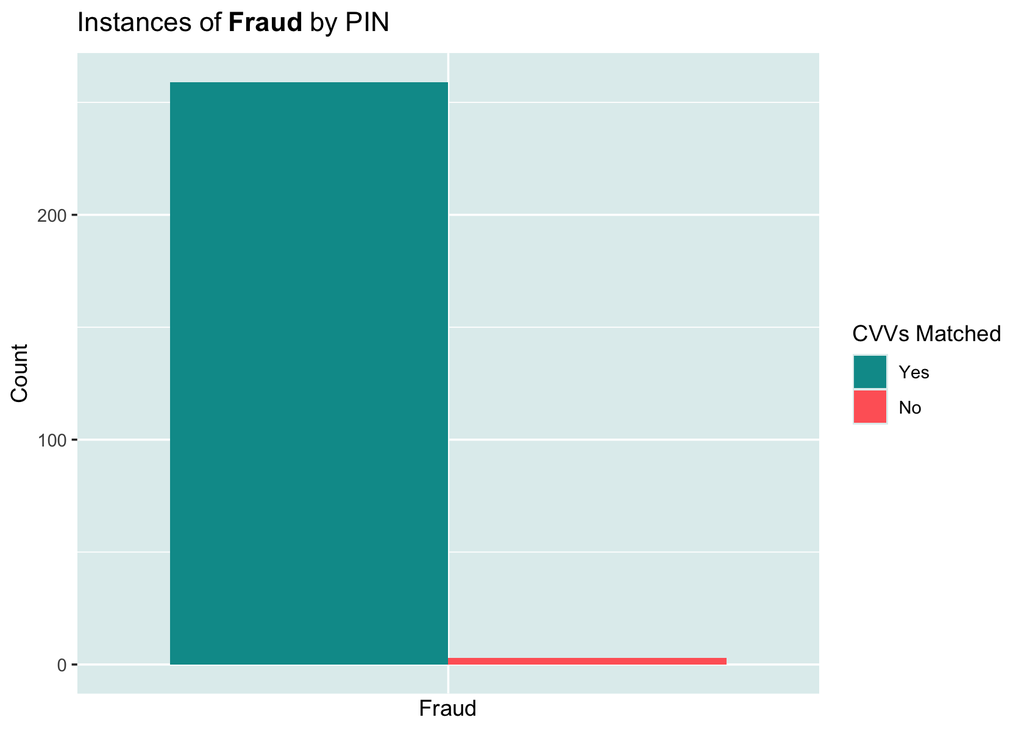

```r
f %>%
  group_by(isFraud, wrongPin) %>%
  count() %>%
  rename(count = n) %>%
  filter(isFraud == 1) %>%
  ggplot(., aes(x = as.factor(isFraud), y=count, fill=as.factor(wrongPin))) +
    geom_bar(stat = 'identity', position = 'dodge') +
    theme(panel.background = element_rect(fill = 'azure2'), panel.grid = element_line(color = 'white'),
          axis.ticks.x=element_blank(), axis.text.x=element_blank()) +
    scale_fill_manual(labels = c('Yes', 'No'), values = c('#009999', '#FF6666')) +
    labs(title = bquote('Instances of' ~ bold('Fraud') ~'by PIN'), x = 'Fraud', y = 'Count',
         fill = 'CVVs Matched')
```

Not the big kahuna I was hoping it to be, but that’s alright.

It’s important that we create a balanced sample before proceeding. We don’t want one value of the dependent variable to drown out the other in the sample. Let’s do that.

```r
set.seed(42)
# Balance to 1:1 by keeping all fraud and downsampling non-fraud to the same n.
# (The old sample_frac(0.016) targeted the full Capital One dump, not this 20k extract.)
f_1 <- f %>% filter(isFraud == 1)
f_0 <- f %>%
  filter(isFraud == 0) %>%
  slice_sample(n = nrow(f_1), replace = FALSE)

g <- bind_rows(f_0, f_1)
tibble(
  n_fraud = nrow(f_1),
  n_nonfraud_kept = nrow(f_0),
  n_balanced = nrow(g),
  fraud_rate_in_f = mean(f$isFraud)
)
```

```
## # A tibble: 1 × 4
##   n_fraud n_nonfraud_kept n_balanced fraud_rate_in_f
##     <int>           <int>      <int>           <dbl>
## 1     262             262        524          0.0140
```

```r
g <- g %>%
  select(-one_of(c('expirationDateKeyInMatch')))
# Snapshot before Model 2 scales `g` in place; Model 3 reuses this exact frame.
g_model1 <- g
```

## Model 1: Plain Vanilla Logistic Regression

Let’s try our first model, which will be a regular machine learning (ML) one. We shall switch back to Python for this.

```r
g_pd <- r_to_py(g)
```

```python
r.g_pd
```

```
##      accountNumber   customerId  ...  topOffender  wrongPin
## 0      745217385.0  745217385.0  ...          1.0       0.0
## 1      114896048.0  114896048.0  ...          1.0       0.0
## 2      863456981.0  863456981.0  ...          1.0       0.0
## 3      745217385.0  745217385.0  ...          1.0       0.0
## 4      763639233.0  763639233.0  ...          1.0       0.0
## ..             ...          ...  ...          ...       ...
## 519    123648720.0  123648720.0  ...          1.0       0.0
## 520    699572278.0  699572278.0  ...          1.0       0.0
## 521    128258324.0  128258324.0  ...          0.0       0.0
## 522    128258324.0  128258324.0  ...          0.0       0.0
## 523    265710406.0  265710406.0  ...          1.0       0.0
##
## [524 rows x 13 columns]
```

```python
df2 = r.g_pd.copy()
```

We already balanced the sample, converted to numeric, and dropped `NA`s. There’s not much left in the way of preprocessing, but let’s scale and one hot encode.

```python
# test = df2.copy()
```

```r
# py_install('sklearn') # pip3 install sklearn
```

Some helper functions to massage the data to the right form for feeding into the model.

```python
import numpy as np

from sklearn.compose import ColumnTransformer
from sklearn.pipeline import Pipeline
#  sklearn.impute import SimpleImputer
from sklearn.preprocessing import StandardScaler, OneHotEncoder
from sklearn.linear_model import LogisticRegression
from sklearn.model_selection import train_test_split, GridSearchCV
```

```python
num_features = ['creditLimit', 'availableMoney', 'transactionAmount', 'cardLast4Digits', 'currentBalance']
num_transformer = Pipeline(steps=[('scaler', StandardScaler())])

cat_features = ['accountNumber', 'customerId', 'merchantCategoryCode', 'cardPresent', # 'isFraud',
                'theWeeHoursTransactions', 'topOffender', 'wrongPin']
cat_transformer = Pipeline(steps=[('onehot', OneHotEncoder(handle_unknown='ignore'))])

preprocess = ColumnTransformer(transformers=[('num', num_transformer, num_features),
                                             ('cat', cat_transformer, cat_features)])
```

```python
# reticulate conversion seems to have made floats out of int64, let's change that back
df2['accountNumber'] = df2['accountNumber'].apply(lambda x: int(x))
df2['customerId'] = df2['customerId'].apply(lambda x: int(x))
df2['creditLimit'] = df2['creditLimit'].apply(lambda x: int(x))
df2['merchantCategoryCode'] = df2['merchantCategoryCode'].apply(lambda x: int(x))
df2['cardLast4Digits'] = df2['cardLast4Digits'].apply(lambda x: int(x))
df2['cardPresent'] = df2['cardPresent'].apply(lambda x: int(x))
df2['isFraud'] = df2['isFraud'].apply(lambda x: int(x))
df2['theWeeHoursTransactions'] = df2['theWeeHoursTransactions'].apply(lambda x: int(x))
df2['topOffender'] = df2['topOffender'].apply(lambda x: int(x))
df2['wrongPin'] = df2['wrongPin'].apply(lambda x: int(x))
```

```python
# df2.groupby('wrongPin').count()
```

```python
X = df2.drop('isFraud', axis=1)
y = df2['isFraud']

X_train, X_test, y_train, y_test = train_test_split(X, y, test_size=0.2, random_state = 42) # reserve 20% for testing
```

```python
preprocess = preprocess.fit(X_train)
```

```python
def myPreprocessor(data):
  preprocessed_data=preprocess.transform(data)
  return preprocessed_data
```

```python
myPreprocessor(X_train).shape
```

```
## (419, 205)
```

```python
print(X_train.shape, X_test.shape,
      y_train.shape, y_test.shape)
```

```
## (419, 12) (105, 12) (419,) (105,)
```

```python
hyperparams = {'C':np.logspace(1, 10, 100), 'penalty':['l2'], 'max_iter':[100]} # 'max_iter':[5]

logit = LogisticRegression()
logitCv = GridSearchCV(logit, hyperparams, cv = 10)
logitCv.fit(myPreprocessor(X_train), y_train)
```

```
GridSearchCV(cv=10, estimator=LogisticRegression(),
             param_grid={'C': array([1.00000000e+01, 1.23284674e+01, 1.51991108e+01, 1.87381742e+01,
       2.31012970e+01, 2.84803587e+01, 3.51119173e+01, 4.32876128e+01,
       5.33669923e+01, 6.57933225e+01, 8.11130831e+01, 1.00000000e+02,
       1.23284674e+02, 1.51991108e+02, 1.87381742e+02, 2.31012970e+02,
       2.84803587e+02, 3.51119173e+02, 4.32876...
       8.11130831e+07, 1.00000000e+08, 1.23284674e+08, 1.51991108e+08,
       1.87381742e+08, 2.31012970e+08, 2.84803587e+08, 3.51119173e+08,
       4.32876128e+08, 5.33669923e+08, 6.57933225e+08, 8.11130831e+08,
       1.00000000e+09, 1.23284674e+09, 1.51991108e+09, 1.87381742e+09,
       2.31012970e+09, 2.84803587e+09, 3.51119173e+09, 4.32876128e+09,
       5.33669923e+09, 6.57933225e+09, 8.11130831e+09, 1.00000000e+10]),
                         'max_iter': [100], 'penalty': ['l2']})
```

```python
print('Best Parameters: ', logitCv.best_params_)
```

```
## Best Parameters:  {'C': np.float64(10.0), 'max_iter': 100, 'penalty': 'l2'}
```

```python
# list(logitCv.best_params_.values())[0]
```

```python
model = LogisticRegression(C = list(logitCv.best_params_.values())[0], penalty = 'l2')

model.fit(myPreprocessor(X_train), y_train) # Fitting to the training set.
```

```
LogisticRegression(C=np.float64(10.0))
```

```python
model.score(myPreprocessor(X_train), y_train) # Fit score, 0-1 scale.
```

```
## 0.7780429594272077
```

```python
y_pred = model.predict(myPreprocessor(X_test))
```

```python
y_pred
```

```
## array([1, 0, 0, 0, 0, 0, 0, 0, 0, 0, 0, 0, 0, 1, 1, 0, 0, 0, 0, 0, 0, 1,
##        1, 1, 1, 1, 1, 0, 1, 0, 1, 0, 1, 0, 1, 0, 1, 0, 1, 0, 0, 0, 1, 0,
##        1, 0, 0, 0, 0, 0, 0, 0, 0, 0, 0, 1, 1, 1, 1, 1, 1, 1, 0, 1, 0, 1,
##        0, 1, 0, 1, 0, 0, 0, 0, 0, 0, 0, 0, 0, 0, 0, 0, 1, 1, 0, 1, 0, 1,
##        1, 0, 1, 1, 0, 1, 1, 0, 0, 1, 1, 1, 1, 1, 1, 1, 0])
```

```python
from sklearn.metrics import accuracy_score

print("Accuracy: {:.2f}%".format(accuracy_score(y_test, y_pred)*100))
```

```
## Accuracy: 70.48%
```

Better than tossing a coin, but we might do better still. Let’s use Bayesian inference for the job. We’ll switch back to R to call Stan that way. Let’s do logits to cf. regular machine learning with Bayesian workflow, performance-wise.

## Model 2: Bayesian Logistic Regression

```r
# a tiny bit of additional preprocessing like in python
g <- g %>%
  dplyr::mutate_at(vars(starts_with(colnames(g)[1:8])), ~c(scale(., center = T, scale = T)))
```

```r
# g$isFraud <- factor(g$isFraud)
#
# X <- model.matrix(isFraud ~ ., data = g)
# y <- g$isFraud
```

```r
library(rstanarm)
library(loo)
```

```r
library(bayesplot)
options(mc.cores = max(1L, parallel::detectCores() - 1L))
```

It’s very important that we check again how balanced the sample is with respect to the dependent variable. Computing the model matrix inverse would fail from precompiled `stan_glm()` models, should the data not be balanced out.

```r
thisFormula <- formula(paste("isFraud ~", paste(colnames(g)[1:(dim(g)[2]-1)][c(-10, -4, -5, -8, -1, -2, -7)], collapse = " + "))) # [-10] # must remove underrepresented vars lest r shouldn't be able to inverse the matrix (i.e. the code would fail)
```

The resultant formula is sparse but let’s cautiously proceed.

```r
formula(paste("isFraud ~", paste(colnames(g)[1:(dim(g)[2]-1)][c(-10, -4, -5, -8, -1, -2, -7)], collapse = " + ")))
```

```
## isFraud ~ creditLimit + merchantCategoryCode + cardPresent +
##     theWeeHoursTransactions + topOffender
```

```r
g$isFraud <- factor(g$isFraud)

X <- model.matrix(thisFormula, data = g)
y <- g$isFraud
```

```r
# can check the iversion
# MASS::ginv(X) # take inverse of a matrix
```

```r
# Student-t priors; QR for geometry; full default-length MCMC (not shortened).
t_prior <- student_t(df = 7, location = 0, scale = 2.5)
post1 <- stan_glm(
  thisFormula,
  data = g,
  family = binomial(link = "logit"),
  prior = t_prior,
  prior_intercept = t_prior,
  QR = TRUE,
  chains = 4,
  iter = 2000,
  warmup = 1000,
  seed = 42,
  refresh = 0
)
```

```r
# dim(g)[2]
```

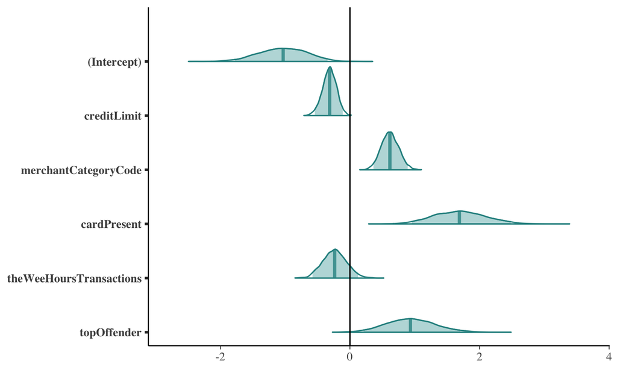

```r
# Project-native bayesplot scheme (this write-up always used teal).
bayesplot::color_scheme_set("teal")
plot(post1, "areas", prob = 0.95, prob_outer = 1) +
  geom_vline(xintercept = 0)
```

```r
round(coef(post1), 2)
```

```
##             (Intercept)             creditLimit    merchantCategoryCode
##                   -1.03                   -0.31                    0.62
##             cardPresent theWeeHoursTransactions             topOffender
##                    1.69                   -0.24                    0.93
```

```r
round(posterior_interval(post1, prob = 0.9), 2)
```

```
##                            5%   95%
## (Intercept)             -1.64 -0.45
## creditLimit             -0.50 -0.14
## merchantCategoryCode     0.40  0.84
## cardPresent              1.06  2.36
## theWeeHoursTransactions -0.53  0.07
## topOffender              0.33  1.58
```

```r
# PSIS-LOO; refit observations with large Pareto-k (rstanarm k_threshold).
loo1 <- loo(post1, save_psis = TRUE, k_threshold = 0.7)
print(loo1)
```

```
##
## Computed from 4000 by 524 log-likelihood matrix.
##
##          Estimate   SE
## elpd_loo   -339.1  7.7
## p_loo         6.2  0.6
## looic       678.1 15.4
## ------
## MCSE of elpd_loo is 0.0.
## MCSE and ESS estimates assume independent draws (r_eff=1).
##
## All Pareto k estimates are good (k < 0.7).
## See help('pareto-k-diagnostic') for details.
```

```r
post0 <- update(
  post1,
  formula = isFraud ~ 1,
  QR = FALSE,
  refresh = 0
)
```

```r
loo0 <- loo(post0, k_threshold = 0.7)
print(loo0)
```

```
##
## Computed from 4000 by 524 log-likelihood matrix.
##
##          Estimate  SE
## elpd_loo   -364.2 0.0
## p_loo         1.0 0.0
## looic       728.4 0.1
## ------
## MCSE of elpd_loo is 0.0.
## MCSE and ESS estimates assume independent draws (r_eff=1).
##
## All Pareto k estimates are good (k < 0.7).
## See help('pareto-k-diagnostic') for details.
```

```r
loo_compare(loo0, loo1) # `post1` better if covariates carry predictive information
```

```
##       elpd_diff se_diff
## post1   0.0       0.0
## post0 -25.1       7.7
```

```r
preds <- posterior_epred(post1)
pred <- colMeans(preds)
pr <- as.integer(pred >= 0.5)
y_num <- as.integer(as.character(y))

# posterior classification accuracy
round(mean(pr == y_num), 2)
```

```
## [1] 0.62
```

```r
# posterior balanced classification accuracy
round(
  (
    mean(pr[y_num == 0] == 0) +
      mean(pr[y_num == 1] == 1)
  ) / 2,
  2
)
```

```
## [1] 0.62
```

Leave-one-out predictive probabilities via `rstanarm::loo_predict` (PSIS-LOO mean predictions):

```r
ploo <- loo_predict(
  post1,
  type = "mean",
  psis_object = loo1$psis_object
)$value

# loo classification accuracy
round(mean((ploo >= 0.5) == y_num), 2)
```

```
## [1] 0.6
```

```r
# loo balanced classification accuracy
round(
  (
    mean((ploo[y_num == 0] < 0.5)) +
      mean((ploo[y_num == 1] >= 0.5))
  ) / 2,
  2
)
```

```
## [1] 0.6
```

An important consideration, on the face of it, it seems that this performed worse than our plain vanilla model. **But**, (i) we tossed a lot of data to inverse the matrix, which, given more time, we could easily fix by doing a better-balanced sample, and / or by hand-writing the function, *and* (ii) consider how much more robust (and therefore trustworthy) this is.

Importantly also, unlike regular ML, this is a far more explainable model. That is, not a black box. For robustness, modularity, explainability, regular Bayesian workflow, to my mind, bests all else. As to the “hand-writing the function” bit, we mean not doing a precompiled model from a package, but instead writing our own Stan program, and calling the compiler ourselves, which would more readily handle hierarchical models, and messier datasets.

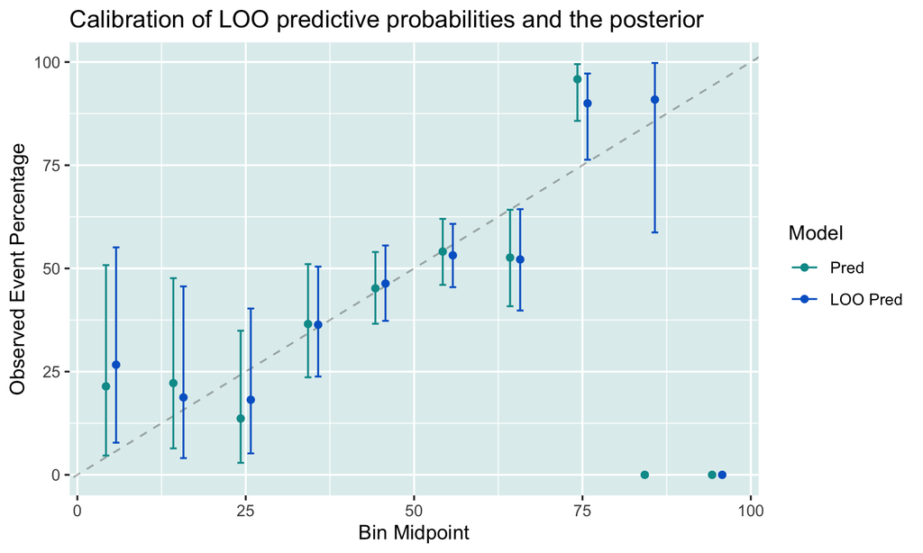

```r
calPlotData <- caret::calibration(
  y ~ pred + loopred,
  data = data.frame(pred = pred, loopred = ploo, y = y),
  cuts = 10,
  class = "1"
)

ggplot(calPlotData, auto.key = list(columns = 2)) +
  theme(
    panel.background = element_rect(fill = "azure2"),
    panel.grid = element_line(color = "white"),
    legend.key = element_rect(colour = "transparent", fill = "white")
  ) +
  scale_color_manual(
    labels = c(pred = "Pred", loopred = "LOO Pred"),
    values = c("#009999", "#0066CC")
  ) +
  labs(title = "Calibration of LOO predictive probabilities and the posterior")
```

## Model 3: Horseshoe logistic via CmdStanPy

The model is a **horseshoe-prior logistic regression** in CmdStanPy (`stan/horseshoe_logit.stan`): global–local shrinkage on coefficients (Carvalho et al.), fit by HMC. Features keep the Model 1 numerics / flags, but replace one-hot account and customer IDs with **train-only smoothed group fraud rates** (empirical-Bayes / target encoding with Laplace smoothing; unseen test IDs fall back to the training base rate). That is partial pooling in feature space rather than a giant sparse dummy design.

```r
nrow(g_model1)
```

```
## [1] 524
```

```python
import os
os.environ.setdefault("MPLCONFIGDIR", "/tmp/mpl")
```

```
## '/tmp/mpl'
```

```python
import numpy as np
import pandas as pd
import matplotlib.pyplot as plt
```

```
## Matplotlib is building the font cache; this may take a moment.
```

```python
import seaborn as sns
from pathlib import Path

from cmdstanpy import CmdStanModel
from sklearn.model_selection import train_test_split
from sklearn.preprocessing import StandardScaler
from sklearn.metrics import (
    accuracy_score,
    balanced_accuracy_score,
    roc_auc_score,
    average_precision_score,
    brier_score_loss,
)

# Same frame / split discipline as Model 1 (snapshot before stan_glm scaled `g`).
df3 = r.g_model1.copy()
for col in [
    "accountNumber",
    "customerId",
    "creditLimit",
    "merchantCategoryCode",
    "cardLast4Digits",
    "cardPresent",
    "isFraud",
    "theWeeHoursTransactions",
    "topOffender",
    "wrongPin",
]:
    df3[col] = df3[col].apply(lambda x: int(x))

y = df3["isFraud"].astype(int)
X = df3.drop(columns=["isFraud"])
X_tr, X_te, y_tr, y_te = train_test_split(
    X, y, test_size=0.2, random_state=42
)

def smooth_rate(
    train_ids: pd.Series, train_y: pd.Series, test_ids: pd.Series, a: float = 2.0
) -> tuple:
    tab = pd.DataFrame({"id": train_ids.to_numpy(), "y": train_y.to_numpy()})
    agg = tab.groupby("id")["y"].agg(["sum", "count"])
    base = float(train_y.mean())
    rate = (agg["sum"] + a * base) / (agg["count"] + a)
    mp = rate.to_dict()
    tr = np.array([mp[i] for i in train_ids], dtype=float)
    te = np.array([mp.get(i, base) for i in test_ids], dtype=float)
    return tr, te

num_cols = [
    "creditLimit",
    "availableMoney",
    "transactionAmount",
    "cardLast4Digits",
    "currentBalance",
]
bin_cols = [
    "cardPresent",
    "theWeeHoursTransactions",
    "topOffender",
    "wrongPin",
]

a_tr, a_te = smooth_rate(X_tr["accountNumber"], y_tr, X_te["accountNumber"])
c_tr, c_te = smooth_rate(X_tr["customerId"], y_tr, X_te["customerId"])
m_tr, m_te = smooth_rate(
    X_tr["merchantCategoryCode"], y_tr, X_te["merchantCategoryCode"]
)

def design_matrix(
    frame: pd.DataFrame, acct: np.ndarray, cust: np.ndarray, mcc: np.ndarray
) -> np.ndarray:
    amt = np.log1p(frame["transactionAmount"].to_numpy(dtype=float))
    util = frame["currentBalance"].to_numpy(dtype=float) / np.maximum(
        frame["creditLimit"].to_numpy(dtype=float), 1.0
    )
    return np.column_stack(
        [
            frame[num_cols].to_numpy(dtype=float),
            frame[bin_cols].to_numpy(dtype=float),
            acct,
            cust,
            mcc,
            amt,
            util,
            acct * amt,
            acct * frame["topOffender"].to_numpy(dtype=float),
        ]
    )

X_tr_raw = design_matrix(X_tr, a_tr, c_tr, m_tr)
X_te_raw = design_matrix(X_te, a_te, c_te, m_te)
scaler = StandardScaler().fit(X_tr_raw)
X_tr_s = scaler.transform(X_tr_raw)
X_te_s = scaler.transform(X_te_raw)

stan_path = Path("stan/horseshoe_logit.stan")
hs_model = CmdStanModel(stan_file=str(stan_path))
fit = hs_model.sample(
    data={
        "N": int(X_tr_s.shape[0]),
        "K": int(X_tr_s.shape[1]),
        "X": X_tr_s,
        "y": y_tr.to_numpy(dtype=int).tolist(),
        "N_new": int(X_te_s.shape[0]),
        "X_new": X_te_s,
    },
    chains=4,
    parallel_chains=4,
    iter_warmup=1500,
    iter_sampling=1500,
    adapt_delta=0.98,
    max_treedepth=14,
    seed=42,
    show_progress=False,
    show_console=False,
)

_sum = fit.summary()
_cols = [c for c in ["Mean", "StdDev", "N_Eff", "ESS_bulk", "R_hat"] if c in _sum.columns]
print(_sum.loc[["intercept", "tau"], _cols])
```

```
##                Mean    StdDev  ESS_bulk    R_hat
## intercept  0.279292  0.148938   6100.33  1.00061
## tau        0.161129  0.111356   2120.93  1.00123
```

```python
p_te = fit.stan_variable("p_new").mean(axis=0)
holdout = {
    "accuracy": float(accuracy_score(y_te, p_te >= 0.5)),
    "balanced_accuracy": float(balanced_accuracy_score(y_te, p_te >= 0.5)),
    "roc_auc": float(roc_auc_score(y_te, p_te)),
    "avg_precision": float(average_precision_score(y_te, p_te)),
    "brier": float(brier_score_loss(y_te, p_te)),
}
print("Model 1 reference holdout accuracy: 0.7048")
```

```
## Model 1 reference holdout accuracy: 0.7048
```

```python
print("CmdStanPy horseshoe holdout:")
```

```
## CmdStanPy horseshoe holdout:
```

```python
pd.Series(holdout)
```

```
## accuracy             0.714286
## balanced_accuracy    0.711735
## roc_auc              0.751458
## avg_precision        0.750662
## brier                0.209817
## dtype: float64
```

```python
# One chart, USER_RULES notebook aesthetics (this project only): hatched KDEs
# of holdout predictive scores under the horseshoe model, by true label.

plt.rcParams["figure.dpi"] = 150
plt.rcParams["hatch.linewidth"] = 0.5
myFont = {"family": "monospace"}
plt.rc("font", **myFont)
sns.set_style("white")

palette = sns.color_palette("mako_r", 10)[::3]
col0, col1 = palette[0], palette[1]

fig, ax = plt.subplots(figsize=(7.2, 4.2))
for lab, col, hatch in [
    (0, col0, "////"),
    (1, col1, "\\\\\\\\"),
]:
    vals = p_te[y_te.to_numpy() == lab]
    sns.kdeplot(
        vals,
        ax=ax,
        color=col,
        fill=False,
        linewidth=1.2,
        label="non-fraud" if lab == 0 else "fraud",
    )
    from scipy.stats import gaussian_kde

    grid = np.linspace(0.0, 1.0, 256)
    dens = gaussian_kde(vals)(grid)
    ax.fill_between(
        grid,
        dens,
        alpha=0.25,
        facecolor="none",
        edgecolor=col,
        hatch=hatch,
        linewidth=0.0,
    )

ax.set_xlim(0.0, 1.0)
```

```
## (0.0, 1.0)
```

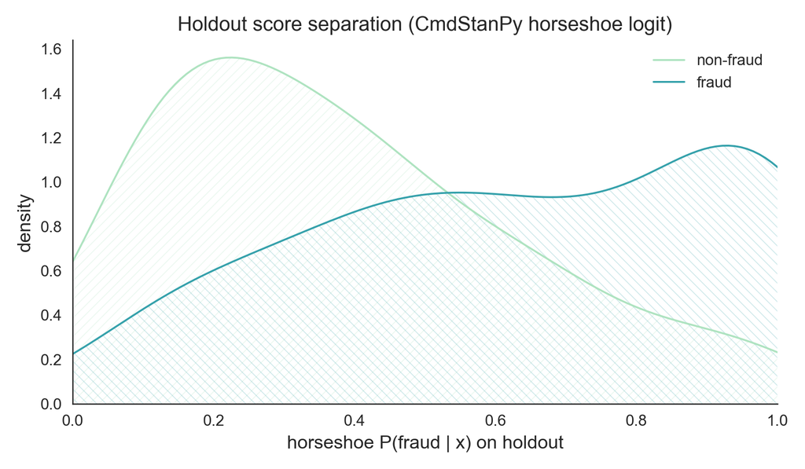

```python
ax.set_xlabel("horseshoe P(fraud | x) on holdout")
ax.set_ylabel("density")
ax.set_title("Holdout score separation (CmdStanPy horseshoe logit)")
ax.tick_params(labelsize=10)
ax.xaxis.label.set_size(12)
ax.yaxis.label.set_size(12)
ax.title.set_size(13)
ax.legend(frameon=False, fontsize=10)
sns.despine(ax=ax)
plt.tight_layout()
plt.show()
```